# First look at the data

Maria Cuellar

2025-09-16

# Change appearance colors in RStudio

Navigate to Tools > Global Options > Appearance (or RStudio > Preferences > Appearance on macOS) and select a desired theme from the dropdown menu.

# Load data

Load the tidyverse - a package that will give you lots of tools.

```r
library(tidyverse)
```

Load data (make sure you name it as an object with a useful name)

```r
dat_kentucky <- read_csv("/Users/mariacuellar/Github/crim_data_analysis/data/kentucky-derby-2018.csv")
dat_students <- read_csv("/Users/mariacuellar/Github/crim_data_analysis/data/students.csv")
```

# Data selection

How to select an observation:

```r
year1986 <- dat_kentucky %>% filter(Year==1986)

year1986
```

```
## # A tibble: 1 × 9
##    Year Year_no Date     Winner     Mins  Secs Time.in.Sec `Distance (mi)`
##   <dbl>   <dbl> <chr>    <chr>     <dbl> <dbl>       <dbl>           <dbl>
## 1  1986     112 3-May-86 Ferdinand     2   2.8        123.            1.25
## # ℹ 1 more variable: `Speed (mph)` <dbl>
```

Note: understand the pipe operator (%>% or |>): The main function of the pipe operator is to take the output of the expression or function on its left-hand side (LHS) and pass it as the first argument to the function on its right-hand side (RHS). This allows you to chain multiple operations together in a clear, sequential manner.

# How to select a variable:

```r
dat_kentucky$Winner
```

```
##   [1] "Aristides"          "Vagrant"            "Baden-Baden"
##   [4] "Day Star"           "Lord Murphy"        "Fonso"
##   [7] "Hindoo"             "Apollo"             "Leonatus"
##  [10] "Buchanan"           "Joe Cotton"         "Ben Ali"
##  [13] "Montrose"           "Macbeth II"         "Spokane"
##  [16] "Riley"              "Kingman"            "Azra"
##  [19] "Lookout"            "Chant"              "Halma"
##  [22] "Ben Brush"          "Typhoon II"         "Plaudit"
##  [25] "Manuel"             "Lieut. Gibson"      "His Eminence"
##  [28] "Alan-a-Dale"        "Judge Himes"        "Elwood"
##  [31] "Agile"              "Sir Huon"           "Pink Star"
##  [34] "Stone Street"       "Wintergreen"        "Donau"
##  [37] "Meridian"           "Worth"              "Donerail"
##  [40] "Old Rosebud"        "Regret"             "George Smith"
##  [43] "*Omar Khayyam"      "Exterminator"       "Sir Barton"
```

[output cut: 33 more lines]

```r
thewinner <- dat_kentucky %>% select(Winner)

thewinner
```

```
## # A tibble: 144 × 1
##    Winner
##    <chr>
##  1 Aristides
##  2 Vagrant
##  3 Baden-Baden
##  4 Day Star
##  5 Lord Murphy
##  6 Fonso
##  7 Hindoo
##  8 Apollo
##  9 Leonatus
## 10 Buchanan
## # ℹ 134 more rows
```

How to select both (observation and variable):

```r
thewinnerin1986 <- dat_kentucky %>%
  filter(Year==1986) %>%
  select(Winner)

thewinnerin1986
```

```
## # A tibble: 1 × 1
##   Winner
##   <chr>
## 1 Ferdinand
```

# First look at the data

Variables in dataset? can look at Data pane, or use names()

```r
names(dat_kentucky)
```

```
## [1] "Year"          "Year_no"       "Date"          "Winner"
## [5] "Mins"          "Secs"          "Time.in.Sec"   "Distance (mi)"
## [9] "Speed (mph)"
```

Type of R variable: can look at the Data pane, or use class()

```r
class(dat_kentucky$Secs)
```

```
## [1] "numeric"
```

Look at dimensions of data: can look at the Data pane, or use dim()

```r
dim(dat_kentucky)
```

```
## [1] 144   9
```

*Note*: the commands let me see what you did.

# Categorical variable as factor

In R, a factor is a special data type used to represent categorical variables, which are variables that take on a limited set of values such as “Male”/“Female” or “Low”/“Medium”/“High”. Factors are stored internally as integers with associated labels, making them both memory-efficient and useful for analysis.

Unlike plain character variables, factors explicitly tell R and tidyverse packages (like ggplot2 and dplyr) that a variable is categorical, which allows for better control over ordering and visualization. You can create factors with the factor() function, customize the level order with the levels argument, or specify an ordered factor when categories have a natural ranking (e.g., “Low” < “Medium” < “High”). See the code below.

Factors are essential for working with categorical data, ensuring correct ordering in plots and statistical models, and preventing unintended numeric operations.

```r
library(tidyverse)

# This is the simplest way to make a categorical variable into a factor
dat_students <- dat_students %>% mutate(year_in_college = as.factor(year_in_college))


# This allows you to set the order of the levels.
dat_students <- dat_students %>%
  mutate(year_in_college = factor(year_in_college, levels = c("1", "2", "3", "4")))
```

# Summarize categorical variable

How to make a table to summarize a categorical variable:

```r
names(dat_students)
```

```
## [1] "name"            "gender"          "age"             "year_in_college"
## [5] "favorite_color"  "grade"
```

```r
table(dat_students$year_in_college) # Base R
```

```
##
## 1 2 3 4
## 0 0 0 0
```

```r
dat_students %>% count(year_in_college) # tidyverse
```

```
## # A tibble: 1 × 2
##   year_in_college     n
##   <fct>           <int>
## 1 <NA>            10497
```

How to make add proportions:

```r
dat_students %>%
  count(year_in_college) %>%
  mutate(prop = n / sum(n))
```

```
## # A tibble: 1 × 3
##   year_in_college     n  prop
##   <fct>           <int> <dbl>
## 1 <NA>            10497     1
```

How to make a table to summarize Two categorical variables:

```r
table(dat_students$favorite_color, dat_students$year_in_college) # It's trickier in tidyverse, but check out the janitor package
```

```
##
##         1 2 3 4
##   blue  0 0 0 0
##   green 0 0 0 0
##   red   0 0 0 0
```

# Visualize quantitative variable

How to draw a histogram:

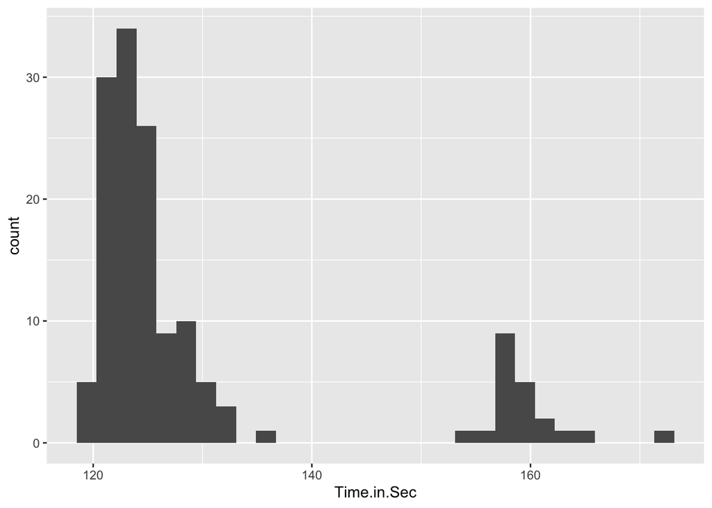

```r
dat_kentucky %>% ggplot(aes(x=Time.in.Sec)) + geom_histogram()
```

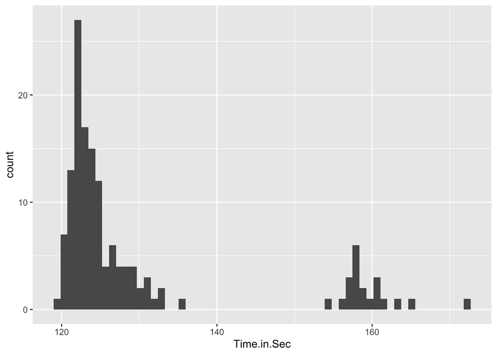

```r
dat_kentucky %>% ggplot(aes(x=Time.in.Sec)) + geom_histogram(bins=60) # Changes number of bins
```

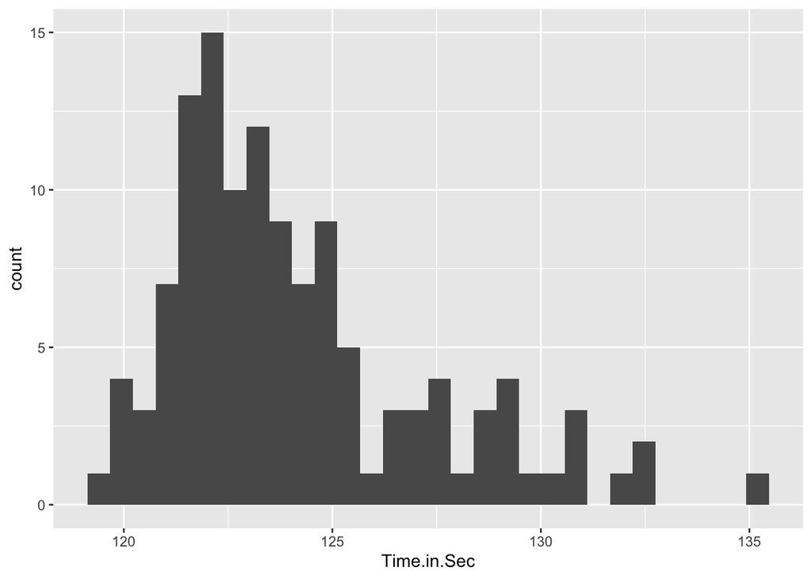

```r
dat_kentucky_lowtime <- dat_kentucky %>% filter(Time.in.Sec<140)

dat_kentucky_lowtime %>% ggplot(aes(x=Time.in.Sec)) + geom_histogram()
```

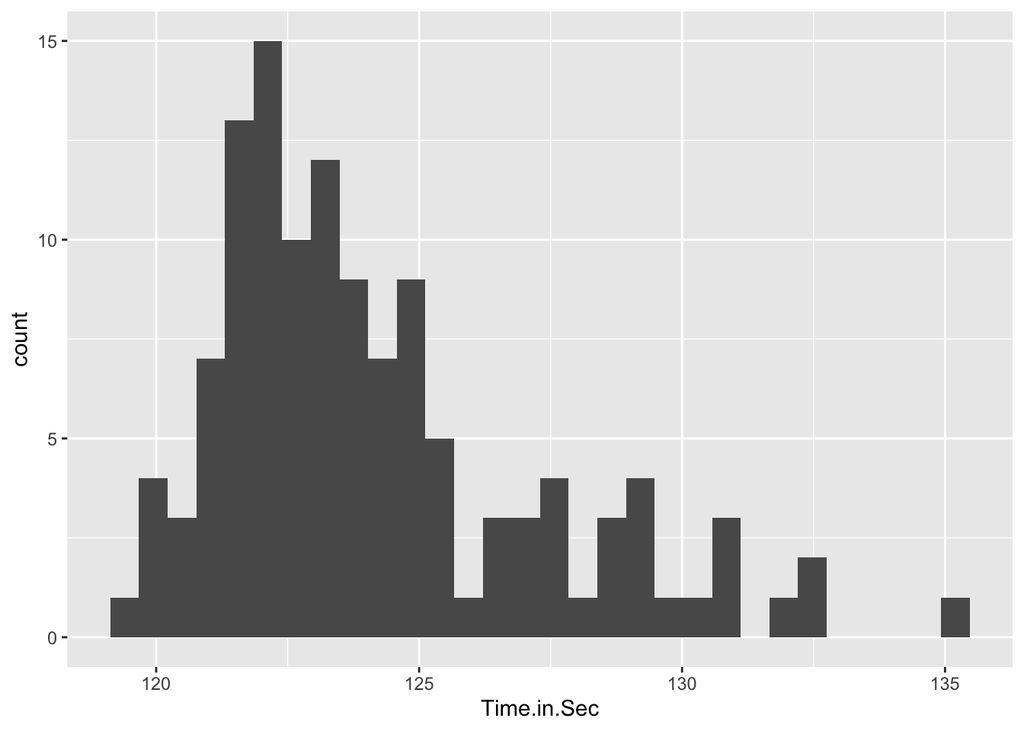

```r
dat_kentucky %>%
  filter(Time.in.Sec < 140) %>%
  ggplot(aes(x=Time.in.Sec)) +
  geom_histogram()
```

You can save the plot as an object

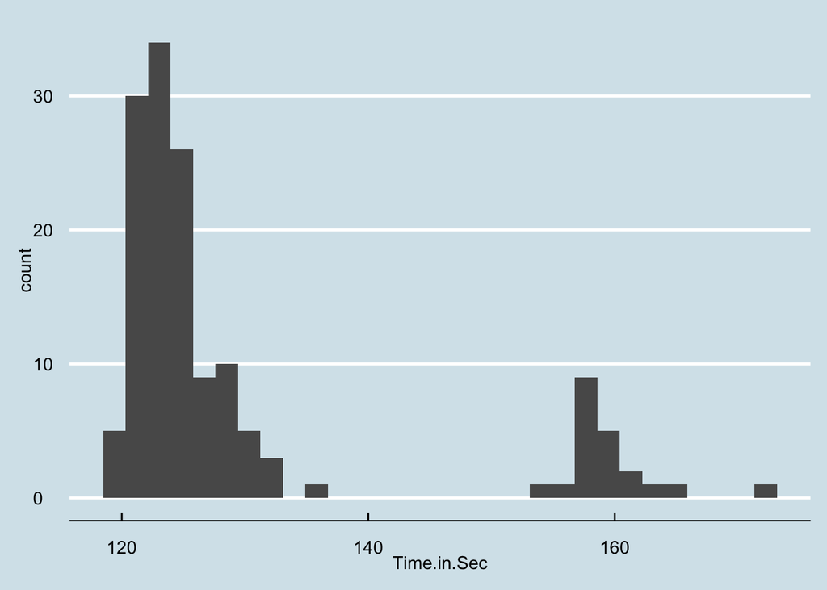

```r
p <- dat_kentucky %>% ggplot(aes(x=Time.in.Sec)) + geom_histogram()

library(ggthemes)
p + theme_economist()
```

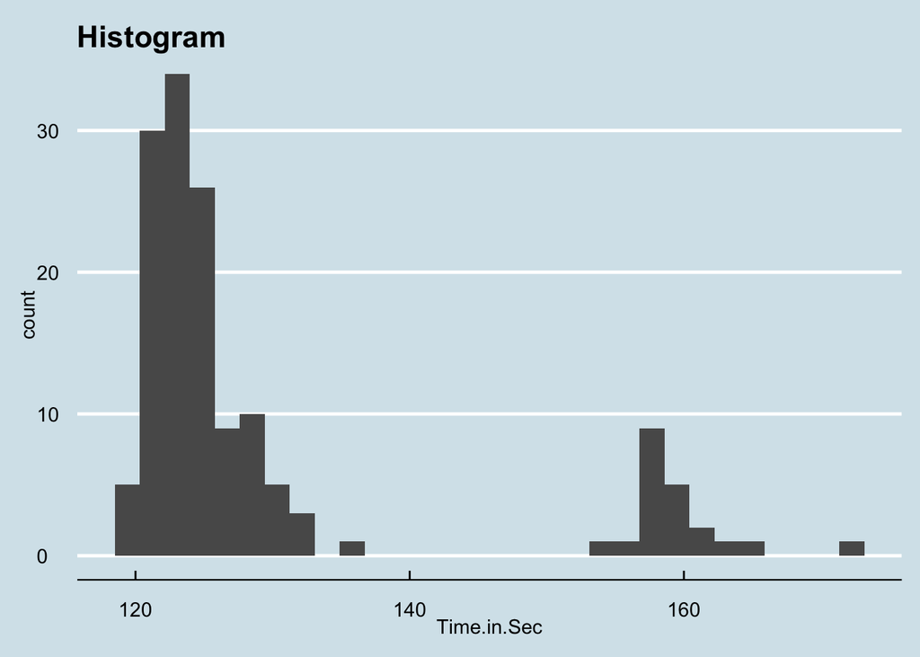

```r
p + labs(title="Histogram") + theme_economist()
```

How to change the aesthetics and labels

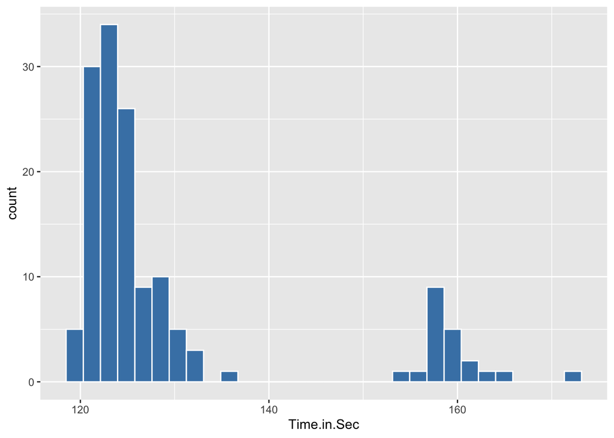

```r
dat_kentucky %>% ggplot(aes(x=Time.in.Sec)) + geom_histogram(bins = 30, fill = "steelblue", color = "white")
```

How to change the aesthetics and labels

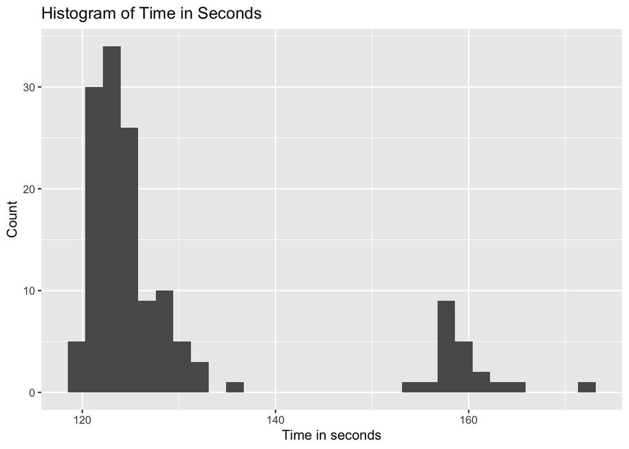

```r
dat_kentucky %>% ggplot(aes(x=Time.in.Sec)) + geom_histogram() +
    labs(
    x = "Time in seconds",   # new label for x-axis
    y = "Count",         # new label for y-axis
    title = "Histogram of Time in Seconds"
  )
```

This is equivalent to

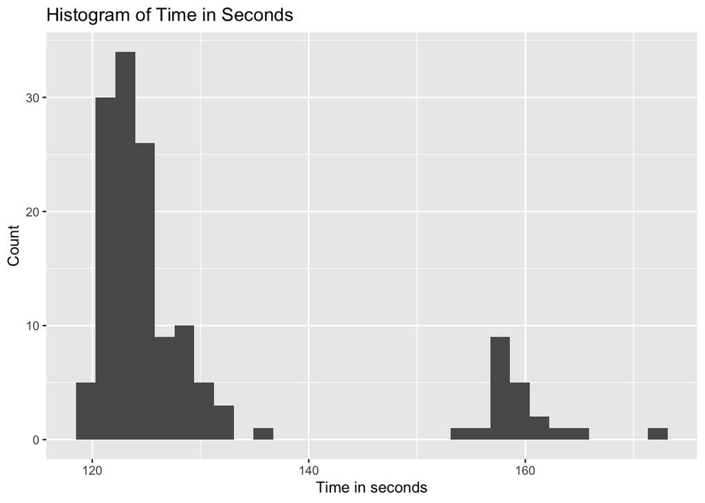

```r
p +
  labs(
    x = "Time in seconds",   # new label for x-axis
    y = "Count",         # new label for y-axis
    title = "Histogram of Time in Seconds"
  )
```

You can change the theme too

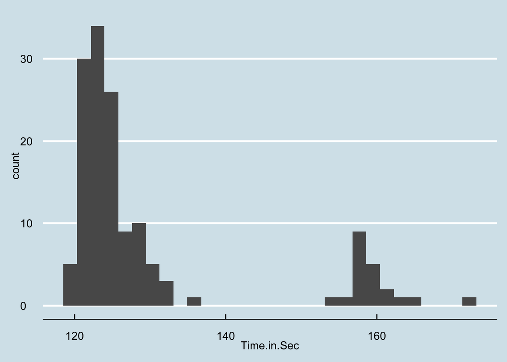

```r
p + theme_economist()
```

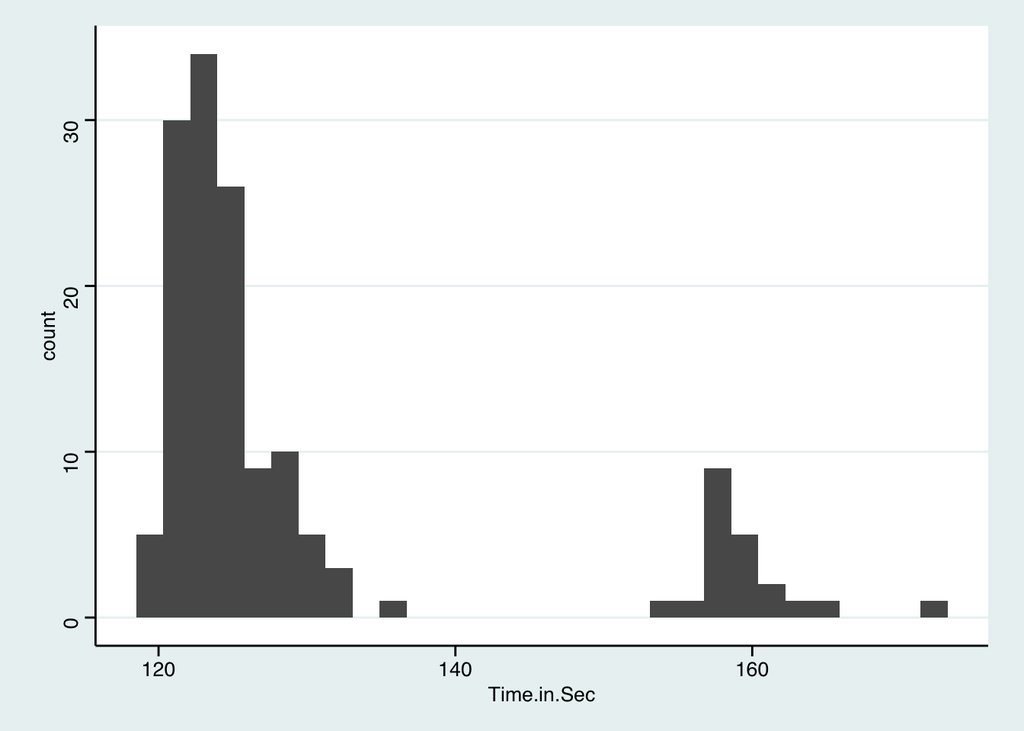

```r
p + theme_stata()
```

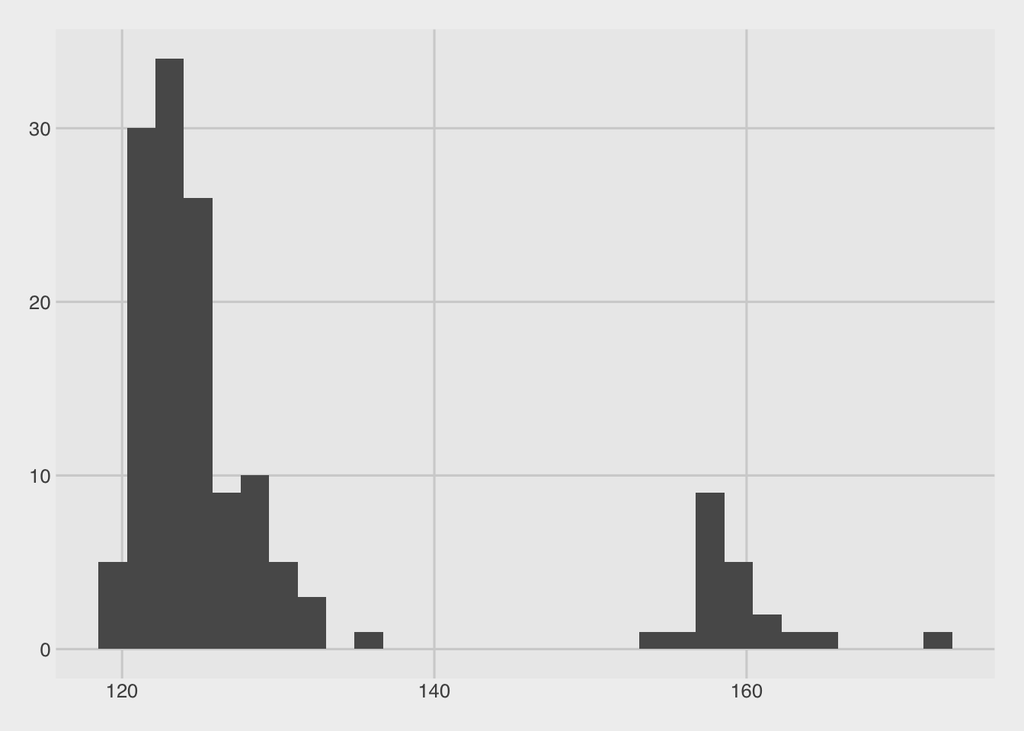

```r
p + theme_fivethirtyeight()
```

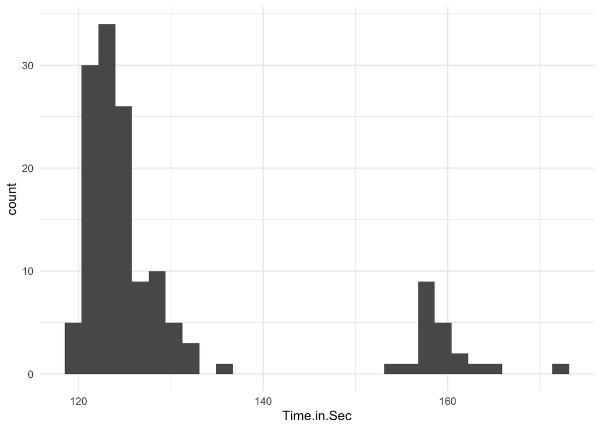

```r
p + theme_minimal()
```

# Visualize categorical variable

How to draw a barplot for YearInCollege

[figure not shown]

```r
# using base R, it's just barplot()
barplot(table(dat_students$year_in_college))
```

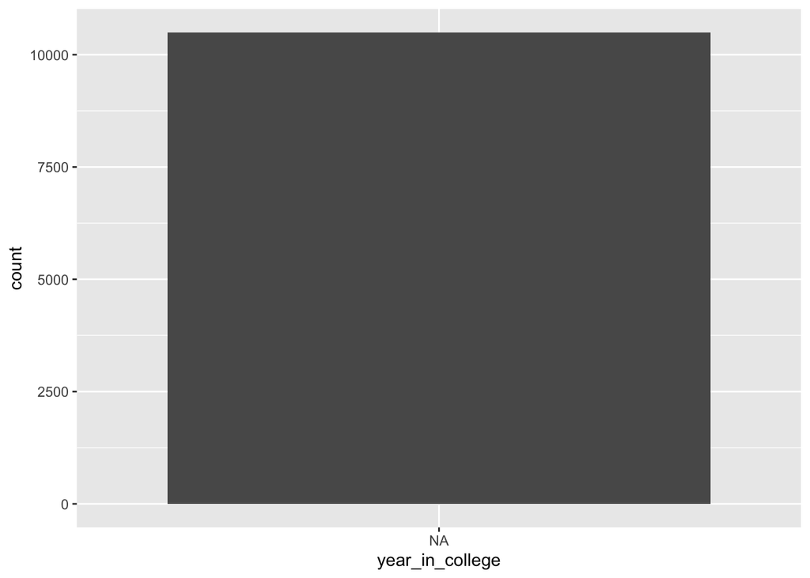

```r
dat_students %>% ggplot(aes(x = year_in_college)) + geom_bar()
```